# Jupyter LabおよびExtensionの紹介

## 今日の資料

https://www.hiromasa.info/posts/17/

## 自己紹介

- 大橋(@wrist)
- PyData Osakaオーガナイザーの一味
- メーカー勤務(音響信号処理屋)
- 近況: バタフライキーボードのbが壊れた

## 本日の実行環境

- Docker上で動作
- `docker pull wrist/jupyterlab-custom:latest`

## 本日の内容

- Jupyter Labの簡単な歴史
- Jupyter Lab単体機能の紹介
- Extensionの紹介

## Jupyter Labの簡単な歴史

- 2016/1/5 first commit
- 2018/2 JupyterLab is Ready for Usersのブログ記事
  - https://blog.jupyter.org/jupyterlab-is-ready-for-users-5a6f039b8906
- 2019/6/28 version 1.0
- 2019/8/28 version 1.1
- 2019/10/29 version 1.2
  - https://jupyterlab.readthedocs.io/en/stable/getting_started/changelog.html

## Jupyter lab単体機能の紹介

### 個人的にJupyter Notebookに求めるもの

- markdown/ipynbでのブログ執筆
- ipynbのスライドへの変換
- vimキーバインド

### キーバインドの設定

- デフォルトで用意
  - `Settings -> Text Editor Key Map`
  - `Sublime Text`, `vim`, `emacs`

### vimキーバインド

- markdown編集などのみに適用
  - cell編集でvimキーバインドが使いたい場合はExtensionが必要
- chrome/safariで使うのが無難？
  - firefoxだとescが効かない

### ショートカット

- ipynbではjupyter notebookのショートカットがそのまま使える
  - 移動 j,k
  - 選択 J,K
  - 挿入 a,b
  - コピペ c,x,v
  - セルタイプ変更 m, y
  - ドキュメント表示 `shift+tab`

```python
# sumにカーソルをあてて`shift+tab`
y = sum([1, 2, 3])
y
```

```
6
```

```python
import scipy as sp
import scipy.signal as sg
```

### labの機能のショートカット(一部)

- コマンドパレット
  - `shift+command+c`
- タブの移動
  - `shift+ctrl+]`
- サイドバーの開閉
  - `command+B`

slide type変更のショートカットがないのが辛い

### Drag&Dropによるセル編集

- ipynb間でも可能

### 画像のペーストによる挿入

- セルにはクリップボード上の画像を`command+v`で挿入可能
- `win+shift+s`や`shift+ctrl+command+4`で選択してキャプチャした矩形画像を挿入

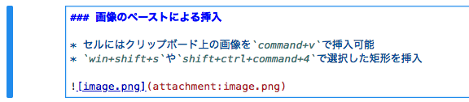

### プレビュー関連

- デフォルトで様々なファイルのプレビューが可能
  - markdown, 画像, csv, JSON, HTML, LaTeX, PDF, Vega/Vega-lite, Virtual DOM
- https://jupyterlab.readthedocs.io/en/stable/user/file_formats.html
  - 動画で説明有

#### Markdownのプレビュー

- markdownファイルを右クリック
  - `Show Markdown Preview`を選択

### リッチな補完

- 補完が見やすい

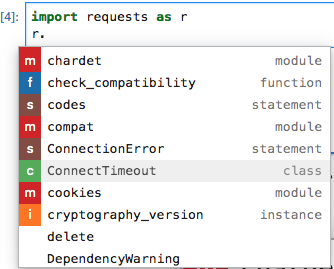

### ipynbのSlideへの変換

- 各セルに`サイドバー -> スパナアイコン -> Slide Type`を設定
- `File -> Export Notebook As... -> Reveal.js`でスライド生成
- RISEはまだ使えない模様
  - リアルタイム修正ができない

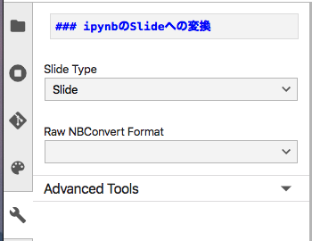

### ipynbへのメタデータの付与

- `スパナアイコン -> Advanced Tools -> Notebook Metadata`で付与可能

## Extensionの紹介

### Extensionの種類

- lab extension
  - フロントエンド側で動作するExtension
  - `jupyter labextension install ...`
- server extension
  - サーバー側で動作するExtension
  - `pip install jupyterlab_git`
  - `jupyter serverextension enable --py jupyterlab_git`

### Extension情報

- githubで`awesome` `jupyter`などを調べる
- おすすめ(スクリーンキャスト付)
  - https://github.com/Yogayu/awesome-jupyterlab-extension
- その他
  - https://github.com/markusschanta/awesome-jupyter#jupyterlab-extensions
  - https://github.com/mauhai/awesome-jupyterlab

### Extension Manger

- GUIでインストールが可能
- コマンドパレットから`Enable Extension Manager`を実行
- サイドバーからExtensionのインストールが可能に

### `@jupyter/toc`

- 目次をサイドバーに表示可能
- アウトラインが分かりやすくなる

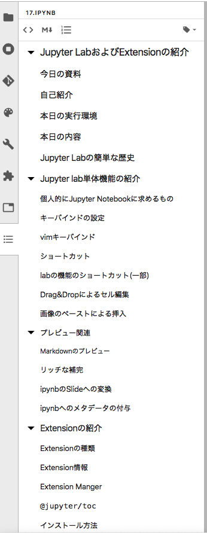

### インストール方法

https://github.com/jupyterlab/jupyterlab-toc

```
jupyter labextension install @jupyter/toc
```

- サイドバーからgit操作が可能
- `nbdime`による差分表示

#### サイドバー

- GUI操作でgit関連操作が可能

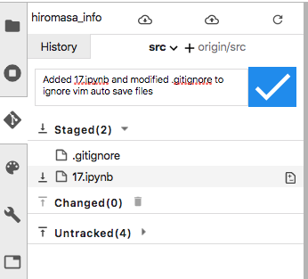

#### 差分表示

- 一番右の2つのアイコン
  - チェックポイントからの差分
  - HEADからの差分

[figure not shown]

### インストール方法

https://github.com/jupyterlab/jupyterlab-git

```
pip install jupyterlab_git
jupyter serverextension enable --py jupyterlab_git
jupyter labextension install @jupyterlab/git
jupyter lab build
```

### `jupyterlab-vim`

- cellの中でもvimキーバインドが使える
  - 割と使い勝手が変わるので好みによる
- セルからの脱出
  - `shift+ctrl+esc`
- セルの確定
  - `ctrl+enter`(エクステンションに関係なく使用可能)

#### コロンをセルの中で押した場合の様子

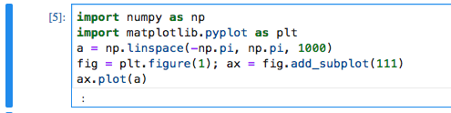

### インストール方法

https://github.com/jwkvam/jupyterlab-vim

```
jupyter labextension install jupyterlab_vim
```

### `@lckr/jupyterlab_variableinspector`

- 変数の一覧表示を実現
  - numpyなどにも対応
  - matrix表示可能
  - `_`に辞書を格納してるっぽい
    - 直前の出力が参照できなくなる

### インストール方法

https://github.com/lckr/jupyterlab-variableInspector

```
jupyter labextension install @lckr/jupyterlab_variableinspector
```

### 使用方法

- 右クリックメニュー
  - `Open Variable Inspector`を選択

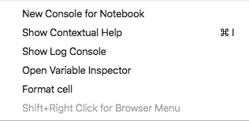

```python
import numpy as np

x = 1
a = np.random.randn(10, 20)
```

#### 変数一覧表示

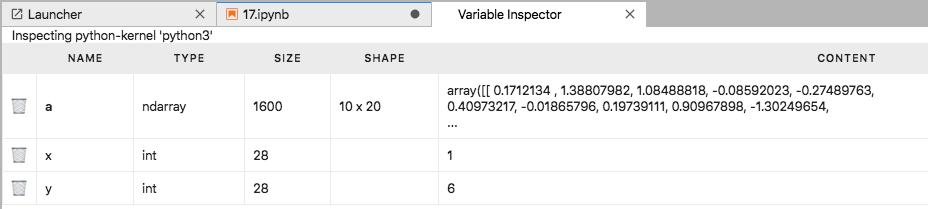

#### ndarrayのmatrix表示

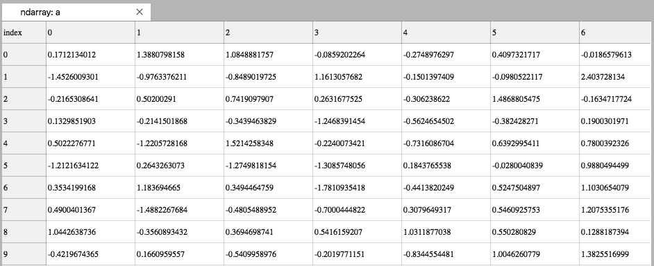

### `@ryantam626/jupyterlab_code_formatter`

- 各種コード整形ライブラリをセルに適用
  - コマンドパレットやipynb上部アイコンから使用

#### コマンドパレットから使用

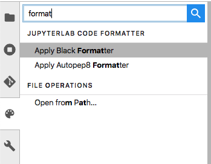

#### アイコンから使用

- 右から3番目のアイコン

[figure not shown]

### インストール方法

https://github.com/ryantam626/jupyterlab_code_formatter

[output not shown]

### 環境構築用のDockerfileの例

```
FROM jupyter/scipy-notebook
MAINTAINER Hiromasa OHASHI <stoicheia1986@gmail.com>

RUN pip install jupyterlab_git jupyterlab_code_formatter autopep8 black
RUN jupyter serverextension enable --py jupyterlab_git
RUN jupyter serverextension enable --py jupyterlab_code_formatter

RUN jupyter labextension install \
  @jupyterlab/toc @jupyterlab/git \
  @lckr/jupyterlab_variableinspector \
  @ryantam626/jupyterlab_code_formatter

RUN jupyter lab build
```

## まとめ

- Jupyter Labの基本的な機能とExtensionを紹介
- 他にも色々便利な機能などあると思いますのでご意見ください